# TP 1 : Linear Regression

## Chargement des packages

```python
import math as m
import numpy as np
import pandas as pd
from sklearn import linear_model, model_selection
from sklearn import preprocessing
from sklearn.model_selection import train_test_split
import urllib
import matplotlib.pyplot as plt
from matplotlib import rc, cm
from mpl_toolkits import mplot3d

from os import mkdir, rmdir, path

%matplotlib notebook
```

## Question 1 :

Commençons par récupérer les données pour en faire des dataframe.

```python
# Chargement des données et création du dataframe df
url = 'https://bitbucket.org/portierf/shared_files/downloads/Galton.txt'
df = pd.read_csv(url, sep='\t')
print('Le fichier contient ' + str(df.shape[0]) + ' lignes.\n')
df.head()
```

```
Le fichier contient 898 lignes.
```

|  | Family | Father | Mother | Gender | Height | Kids |
| --- | --- | --- | --- | --- | --- | --- |
| 0 | 1 | 78.5 | 67.0 | M | 73.2 | 4 |
| 1 | 1 | 78.5 | 67.0 | F | 69.2 | 4 |
| 2 | 1 | 78.5 | 67.0 | F | 69.0 | 4 |
| 3 | 1 | 78.5 | 67.0 | F | 69.0 | 4 |
| 4 | 2 | 75.5 | 66.5 | M | 73.5 | 4 |

```python
# Vérification de données manquantes
null_data = df[df.isnull().any(axis=1)]
print("Il y a " + str(df.isnull().sum().sum()) +
      ' valeurs manquantes.')
```

```
Il y a 0 valeurs manquantes.
```

Il n'y a donc **pas de données manquantes** dans cette table.

## Question 2 :

Ajoutons une colonne "MeanParents" contenant la taille du parent moyen à notre dataframe.

```python
# Création de la colonne "MeanParents" dans le dataframe df
df['MeanParents'] = 0.5 * (df['Father'] + 1.08 * df['Mother'])
df.head()
```

|  | Family | Father | Mother | Gender | Height | Kids | MeanParents |
| --- | --- | --- | --- | --- | --- | --- | --- |
| 0 | 1 | 78.5 | 67.0 | M | 73.2 | 4 | 75.43 |
| 1 | 1 | 78.5 | 67.0 | F | 69.2 | 4 | 75.43 |
| 2 | 1 | 78.5 | 67.0 | F | 69.0 | 4 | 75.43 |
| 3 | 1 | 78.5 | 67.0 | F | 69.0 | 4 | 75.43 |
| 4 | 2 | 75.5 | 66.5 | M | 73.5 | 4 | 73.66 |

On note $x_i$ la taille du parent moyen pour la famille i et $y_i$ la taille de l’enfant. On écrit $y_i = \theta_1 x_i + \theta_0 + \epsilon_i$ et on modélise les variables $\epsilon_i$ comme centrées, indépendantes de même variance $\sigma^2$ inconnue.

## Question 3 :

On va tracer le nuage de point ($x_i$, $y_i$) pour $1 ≤ i ≤ n$ où n est le nombre d’observations figurant dans les données, donc **898** d'après la question 1.

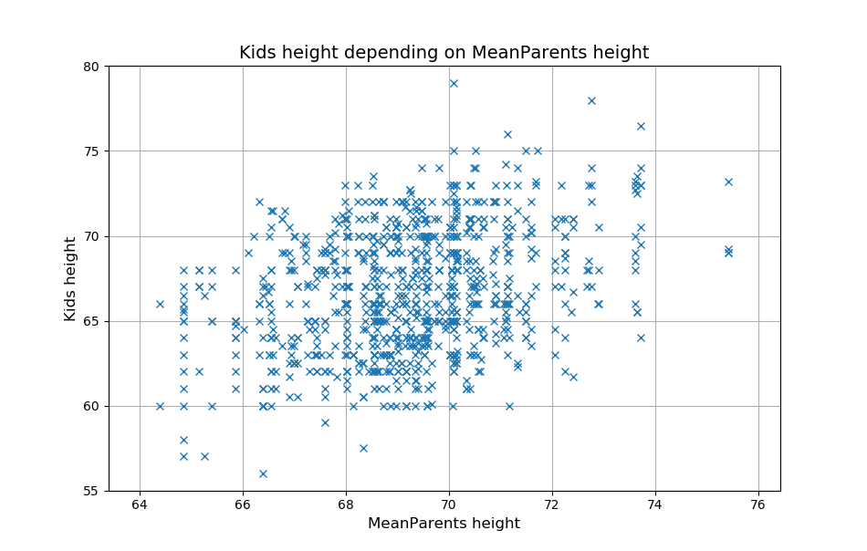

```python
plt.figure()
y = df['Height']
x = df[['MeanParents']]
plt.plot(x, y, 'x',label="")
plt.ylabel('Kids height', fontsize=12)
plt.ylim([df['Height'].min()-1, df['Height'].max()+1])
plt.xlabel('MeanParents height', fontsize=12)
plt.xlim([df['MeanParents'].min()-1, df['MeanParents'].max()+1])
plt.title("Kids height depending on MeanParents height", fontsize=14)
plt.grid(True)
plt.show()
```

## Question 4 :

Estimation de $\theta_0$, $\theta_1$ par $\widehat\theta_0$, $\widehat\theta_1$ en utilisant la fonction `LinearRegression` de `sklearn`.

```python
x = df[['MeanParents']]
y = df['Height']
skl_lm = linear_model.LinearRegression()
skl_lm.fit(x, y) # Entraînement du modèle sur le jeu de données

y_estim = skl_lm.predict(x) # Prédicteur
theta0 = skl_lm.intercept_
y_mean = y.mean()
theta1 = skl_lm.coef_[0]


print('Theta_0 vaut {}'.format(theta0))
print('Theta_1 vaut {}'.format(theta1))
```

```
Theta_0 vaut 22.376205683004223
Theta_1 vaut 0.6411903795908174
```

Calcul et visualisation des valeurs prédites $\widehat y_i = \widehat\theta_1 x_i + \widehat\theta_0$ et $y_i$ sur un même graphique.

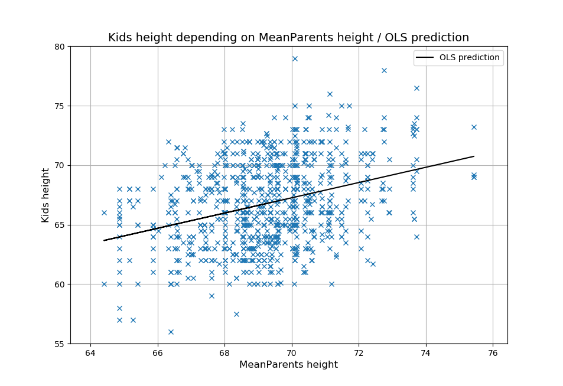

```python
fig = plt.figure()
y = df['Height']
x = df[['MeanParents']]
plt.plot(x, y, 'x',label="")
plt.plot(x, y_estim, label='OLS prediction', c='k')
plt.xlabel('MeanParents height', fontsize=12)
plt.xlim([df['MeanParents'].min()-1, df['MeanParents'].max()+1])
plt.ylabel('Kids height', fontsize=12)
plt.ylim([df['Height'].min()-1, df['Height'].max()+1])
plt.title("Kids height depending on MeanParents height / OLS prediction", fontsize=14)
plt.legend()
plt.grid(True)
plt.show()
```

## Question 5 :

Nous allons recentrer nos données et vérifier que la prédiction effectuée dans le modèle centré est bien la même que celle effectuée précédemment. Pour rappel, les formules du cours nous donnaient :

$\widehat\theta_0= \overline{y}_n -\widehat{\theta}_1 \overline{x}_n$, $\qquad \widehat\theta_1= \displaystyle\frac{\overset{n}{\underset{i=1}{\sum}} (x_i-\overline{x}_n)(y_i -\overline{y}_n)}{\overset{n}{\underset{i=1}{\sum}} (x_i-\overline{x}_n)^2}$

```python
# Calcul des variables centrées
x_center = x - np.mean(x)
y_center = y - np.mean(y)


# Calcul de theta0 et theta1 avec les formules du cours permettant de recentrer les données
theta1_manual = (y_center*(df['MeanParents']-df['MeanParents'].mean())).sum() / (
                        ((df['MeanParents']-df['MeanParents'].mean())**2).sum() )
theta0_manual = 0.0

print('Theta0 "manuel" vaut 0 (données centrées).\n')
print('Theta1 vaut ' + str(theta1))
print('Theta1 "manuel" vaut ' + str(theta1_manual) +'\n')


print('Les deux valeurs de theta1' +
      ' sont-elles identiques ? {}, et theta1={}'.format(np.allclose(theta1, theta1_manual),theta1))
```

```
Theta0 "manuel" vaut 0 (données centrées).

Theta1 vaut 0.6411903795908174
Theta1 "manuel" vaut 0.6411903795908169

Les deux valeurs de theta1 sont-elles identiques ? True, et theta1=0.6411903795908174
```

Ou bien, deuxième méthode de calcul :

```python
skl_lm_center = linear_model.LinearRegression(fit_intercept = False)
skl_lm_center.fit(x_center, y_center)
theta1_center = skl_lm_center.coef_[0]
theta0_center = skl_lm_center.intercept_

print('Les deux valeurs de theta0' +
      ' sont-elles identiques ? {}, et theta0={}'.format(np.allclose(theta0_manual, theta0_center),theta0_center))
print('Les deux valeurs de theta1' +
      ' sont-elles identiques ? {}, et theta1={}'.format(np.allclose(theta1_manual, theta1_center),theta1))
```

```
Les deux valeurs de theta0 sont-elles identiques ? True, et theta0=0.0
Les deux valeurs de theta1 sont-elles identiques ? True, et theta1=0.6411903795908174
```

Nous retrouvons donc bien une **pente identique** sur la droite de régression entre le modèle précédent et le modèle centré.

## Question 6 :

Visualisons l’histogramme des résidus $r_i = y_i − \widehat y_i$, ou ($\widehat y_i$ est la valeur prédite par le modèle)

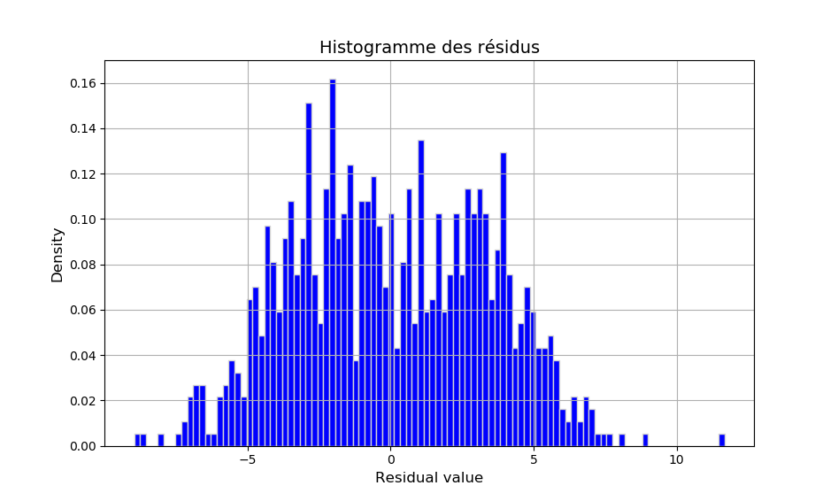

```python
plt.figure()
residual = y - y_estim
#x_grid = np.linspace(-10, 10, num=150)
plt.title('Histogramme des résidus', fontsize=14)
plt.xlabel('Residual value', fontsize=12)
plt.ylabel('Density', fontsize=12)
plt.hist(residual, density=True, bins=100, color='blue', edgecolor = 'lightgrey')
plt.grid(True)
plt.show()
```

**L’hypothèse de normalité globale des résidus ne semble pas crédible**. En effet, la distribution, bien que centrée en zéro, semble être bimodale et n'atteind pas son maximum en zéro. La représentation ci-dessus semble être une addition de 2 gaussiennes. Cela est logique de part la différence entre la taille moyenne des femmes et celle des hommes. Il sera donc plus judicieux de mener l'étude séparement par genre.

## Question 7 :

Sur un graphique similaire à celui de la question 3, sur lequel apparait le nuage de points et la droite de régression, nous allons représenter, à l’aide de deux couleurs différentes, les femmes et les hommes.

```python
homme = df['Gender'] == 'M'
femme = df['Gender'] == 'F'
```

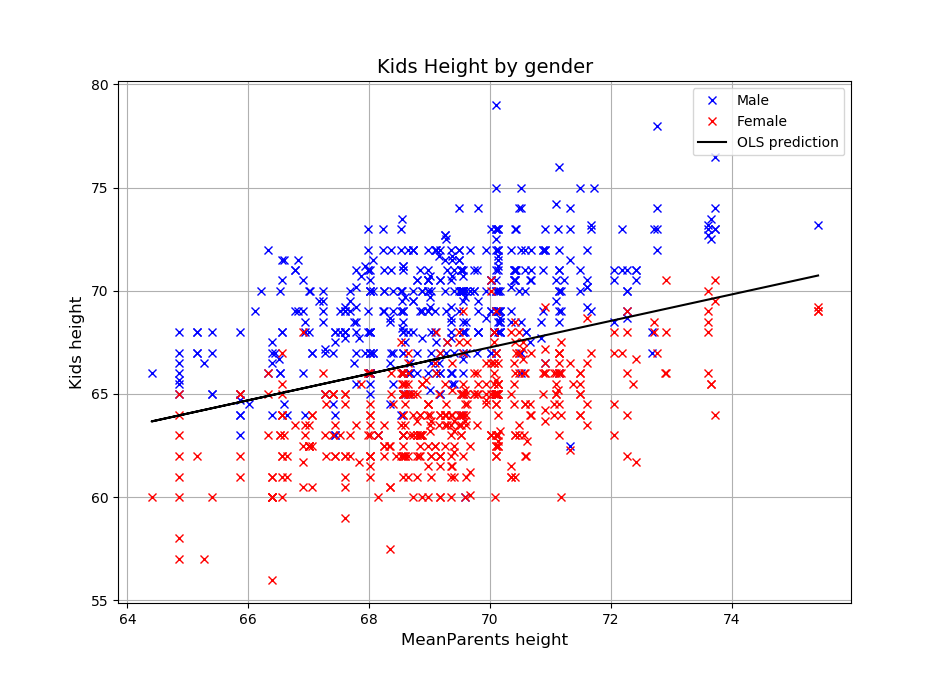

```python
fig = plt.figure()
plt.plot(df['MeanParents'][homme], y[homme], 'x', c='blue', label="Male")
plt.plot(df['MeanParents'][femme], y[femme], 'x', c='red', label="Female")
plt.plot(x, y_estim, label='OLS prediction', c='k')
plt.xlabel('MeanParents height', fontsize=12)
plt.ylabel('Kids height', fontsize=12)
plt.title("Kids Height by gender", fontsize=14)
plt.legend()
plt.grid(True)
plt.show()
```

Comme le montre le graphique ci-dessus, on retrouve bien une **répartition bimodale** avec les hommes globalement plus grand que les femmes. Cela tend donc bien à confirmer ce que nous avons observé en question 6.

## Question 8 :

Effectuons donc une régression sur le groupe des hommes uniquement.

```python
x_H = df[['MeanParents']][homme]
y_H = df['Height'][homme]
skl_lm_H = linear_model.LinearRegression()
skl_lm_H.fit(x_H, y_H)

y_estim_H = skl_lm_H.predict(x_H)
theta0_H = skl_lm_H.intercept_
theta1_H = skl_lm_H.coef_[0]
y_mean_H = y_H.mean()

print('Theta0_H vaut {}'.format(theta0_H))
print('Theta1_H vaut {}'.format(theta1_H))
```

```
Theta0_H vaut 19.990999706486235
Theta1_H vaut 0.7120758362217019
```

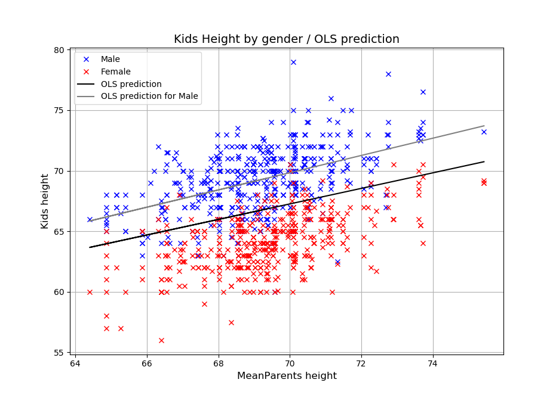

```python
fig = plt.figure()
plt.plot(df['MeanParents'][homme], y[homme], 'x', c='blue', label="Male")
plt.plot(df['MeanParents'][femme], y[femme], 'x', c='red', label="Female")
plt.plot(x, y_estim, label='OLS prediction', c='k')
plt.plot(x_H, y_estim_H, label='OLS prediction for Male', c='grey')
plt.xlabel('MeanParents height', fontsize=12)
plt.ylabel('Kids height', fontsize=12)
plt.title("Kids Height by gender / OLS prediction", fontsize=14)
plt.legend()
plt.grid(True)
plt.show()
```

Représentons alors la distribution des résidus avec ce modèle.

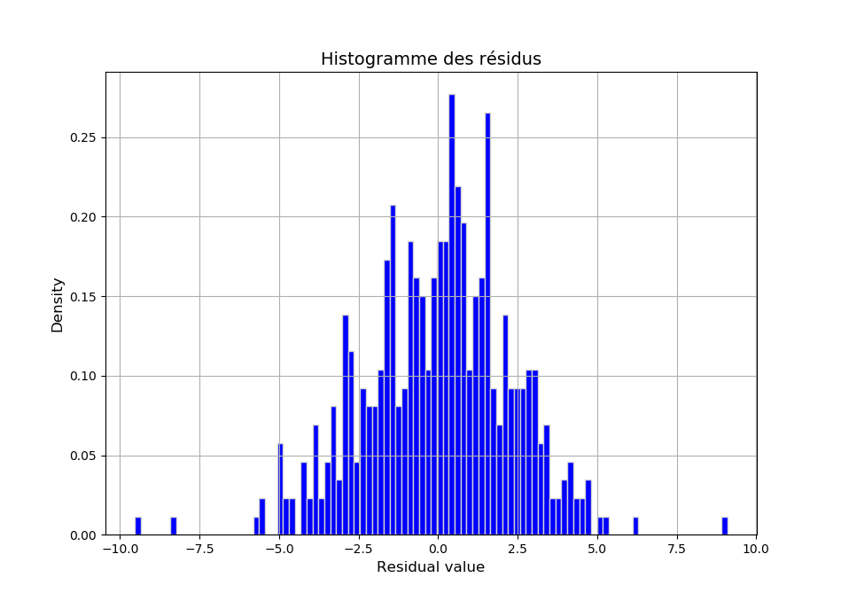

```python
plt.figure()
residual_H = y_H - y_estim_H
plt.title('Histogramme des résidus', fontsize=14)
plt.xlabel('Residual value', fontsize=12)
plt.ylabel('Density', fontsize=12)
plt.hist(residual_H, density=True, bins=100, color='blue', edgecolor = 'lightgrey')
plt.grid(True)
plt.show()
```

Avec ce modèle, les résidus sont beaucoup plus **centrés** qu'avec notre modèle précédent, et la répartition est **unimodale**.

## Question 9 :

A l’aide d’un partitionnement aléatoire de l’échantillon, nous allons construire un échantillon de test et un échantillon d’apprentissage. L’échantillon test contiendra 20% des données.

```python
# Séparation des données avec 20% dans l'échantillon de test

df_train, df_test = train_test_split(df, test_size=0.2)

print("L'échantillon d'apprentissage à la forme suivante : {}".format(df_train.shape))
df_train.head()
```

```
L'échantillon d'apprentissage à la forme suivante : (718, 7)
```

|  | Family | Father | Mother | Gender | Height | Kids | MeanParents |
| --- | --- | --- | --- | --- | --- | --- | --- |
| 654 | 149 | 68.2 | 63.5 | M | 65.5 | 5 | 68.390 |
| 223 | 58 | 71.0 | 62.0 | M | 70.0 | 7 | 68.980 |
| 300 | 75 | 70.0 | 64.7 | M | 72.0 | 7 | 69.938 |
| 314 | 77 | 70.0 | 64.0 | M | 70.0 | 4 | 69.560 |
| 153 | 42 | 71.0 | 65.5 | M | 72.0 | 6 | 70.870 |

```python
print("L'échantillon de test à la forme suivante : {}".format(df_test.shape))
df_test.head()
```

```
L'échantillon de test à la forme suivante : (180, 7)
```

|  | Family | Father | Mother | Gender | Height | Kids | MeanParents |
| --- | --- | --- | --- | --- | --- | --- | --- |
| 19 | 5 | 75.0 | 58.5 | F | 62.5 | 6 | 69.09 |
| 481 | 109 | 69.5 | 64.5 | F | 63.7 | 7 | 69.58 |
| 295 | 73 | 70.0 | 65.0 | M | 73.0 | 3 | 70.10 |
| 801 | 182 | 66.0 | 61.5 | M | 70.0 | 1 | 66.21 |
| 398 | 95 | 70.0 | 58.5 | F | 63.0 | 3 | 66.59 |

Estimons maintenant, sur l’échantillon d’apprentissage `data_train` deux modèles : un premier modèle basé uniquement sur les garçons, et un deuxième modèle basé sur l’échantillon complet. Pour cela, nous utiliserons, comme à la question 4, la fonction `LinearRegression` de `sklearn`.

```python
homme_train = df_train['Gender'] == 'M'
femme_train = df_train['Gender'] == 'F'

homme_test = df_test['Gender'] == 'M'
femme_test = df_test['Gender'] == 'F'

# Calcul du modèle d'entraînement hommes

x_train_H = df_train[['MeanParents']][homme_train]
y_train_H = df_train['Height'][homme_train]
skl_lm_train_H = linear_model.LinearRegression()
skl_lm_train_H.fit(x_train_H, y_train_H)


y_train_estim_H = skl_lm_train_H.predict(x_train_H)
theta0_train_H = skl_lm_train_H.intercept_
theta1_train_H = skl_lm_train_H.coef_[0]
y_train_mean_H = y_train_H.mean()

print('Theta_0_train_H vaut {}'.format(theta0_train_H))
print('Theta_1_train_H vaut {}'.format(theta1_train_H))
```

```
Theta_0_train_H vaut 18.59921164242717
Theta_1_train_H vaut 0.730691630158492
```

```python
# Calcul du modèle d'entraînement complet

x_train = df_train[['MeanParents']]
y_train = df_train['Height']
skl_lm_train = linear_model.LinearRegression()
skl_lm_train.fit(x_train, y_train)


y_estim_train = skl_lm_train.predict(x_train)
theta0_train = skl_lm_train.intercept_
theta1_train = skl_lm_train.coef_[0]
y_train_mean = y_train.mean()

print('Theta_0_train vaut {}'.format(theta0_train))
print('Theta_1_train vaut {}'.format(theta1_train))
```

```
Theta_0_train vaut 21.061782842529702
Theta_1_train vaut 0.6595333086187671
```

```python
# Calcul du prédicteur du modèle global sur l'échantillon de test
x_test = df_test[['MeanParents']]
y_test = df_test['Height']

y_test_estim = skl_lm_train.predict(x_test)
```

```python
# Calcul du prédicteur du modèle homme sur l'échantillon test
x_test_H = df_test[['MeanParents']][homme_test]
y_test_H = df_test['Height'][homme_test]

y_test_estim_H = skl_lm_train_H.predict(x_test_H)
```

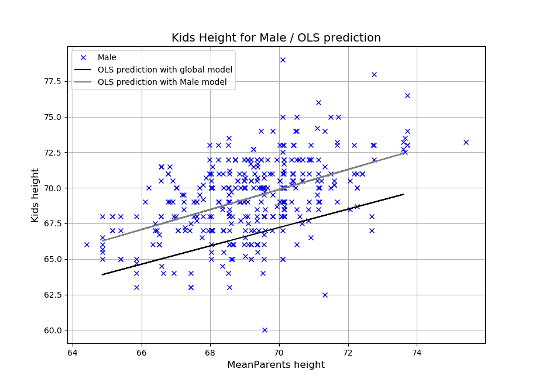

```python
# Repésentons graphiquement ces résultats :

fig = plt.figure()
plt.plot(x_train_H, y_train_H, 'x', c='blue', label="Male")
plt.plot(x_test, y_test_estim, label='OLS prediction with global model', c='k')
plt.plot(x_test_H, y_test_estim_H, label='OLS prediction with Male model', c='grey')
plt.xlabel('MeanParents height', fontsize=12)
plt.ylabel('Kids height', fontsize=12)
plt.title("Kids Height for Male / OLS prediction", fontsize=14)
plt.legend()
plt.grid(True)
plt.show()
```

Comparons alors les deux prédicteurs sur le groupe "hommes" de l’échantillon test `data_test` en calculant le risque de prédiction :

$$ \frac{1}{|test|}\underset{i \in test}{\sum} (y_i - \widehat y_i)² $$

Avec $\widehat y_i$ valeur prédite par le modèle.

```python
# Calcul du risque de prédiction pour les deux modèles

r_predict_test = (1/y_test_H.shape[0])*sum((y_test_H - y_test_estim[homme_test])**2)
print("Le risque de prédiction sur le modèle global vaut {}".format(r_predict_test))

r_predict_test_H = (1/y_test_H.shape[0])*sum((y_test_H - y_test_estim_H)**2)
print("Le risque de prédiction sur le modèle hommes vaut {}".format(r_predict_test_H))
```

```
Le risque de prédiction sur le modèle global vaut 13.71095686561644
Le risque de prédiction sur le modèle hommes vaut 5.223799854480996
```

## Question 10 :

En combinant les deux prédicteurs, celui appris sur les femmes et celui appris sur les hommes, nous allons calculer le risque de prédiction associé. Pour chaque individu "homme" on applique le modèle appris sur les homme, pour chaque individu "femme" on lui applique le modèle appris sur les femmes. On calculera ensuite le risque prédictif.

- Commençons donc par calculer un prédicteur pour le modèle femme, calculé à partir de notre échantillon d'entraîenement et appliquer sur notre échantillon de test.

```python
# Calcul du prédicteur sur le modèle femme
x_train_F = df_train[['MeanParents']][femme_train]
y_train_F = df_train['Height'][femme_train]
skl_lm_train_F = linear_model.LinearRegression()
skl_lm_train_F.fit(x_train_F, y_train_F)

x_test_F = df_test[['MeanParents']][femme_test]
y_test_F = df_test['Height'][femme_test]

y_test_estim_F = skl_lm_train_F.predict(x_test_F)
```

- Calculons alors le risque prédictif combiné des modèles hommes et femmes

```python
r_predict_test_F = (1/y_test_F.shape[0]) * sum((y_test_F - y_test_estim_F)**2)
print("Le risque de prédiction sur le modèle femmes vaut {}".format(r_predict_test_F))


r_predict_test_combined = (1/y_test.shape[0]) * (sum((y_test_H - y_test_estim_H)**2) +
                                             sum((y_test_F - y_test_estim_F)**2))
print("Le risque de prédiction sur le modèle combiné vaut {}".format(r_predict_test_combined))
```

```
Le risque de prédiction sur le modèle femmes vaut 3.594633236395855
Le risque de prédiction sur le modèle combiné vaut 4.463522099374597
```

## Question 11 :

En utilisant, un encodage booléen de la variable *GENDER* nous allons construire le même prédicteur que précédement. Nous calculerons alors, "à la main", son coefficient de determination (R²), et comparerons ce dernier au coefficient de determination du modèle avec seulement la variable MeanParents.

Pour rappel, $$ R^2 = 1 - \frac{\overset{n}{\underset{i=0}{\sum}}(\widehat y_i - y_i)^2}{\overset{n}{\underset{i=0}{\sum}}(\overline y_n - y_i)^2} = \frac{\overset{n}{\underset{i=0}{\sum}}(\widehat y_i - \overline y_n)^2}{\overset{n}{\underset{i=0}{\sum}}(y_i - \overline y_n)^2} $$

- Commençons par encoder la variable *GENDER* avec un booléen

```python
# Remplacement des valeurs M et F par 1 et 0
df.replace('F',0, inplace = True)
df.replace('M',1, inplace = True)
df.head()
```

|  | Family | Father | Mother | Gender | Height | Kids | MeanParents |
| --- | --- | --- | --- | --- | --- | --- | --- |
| 0 | 1 | 78.5 | 67.0 | 1 | 73.2 | 4 | 75.43 |
| 1 | 1 | 78.5 | 67.0 | 0 | 69.2 | 4 | 75.43 |
| 2 | 1 | 78.5 | 67.0 | 0 | 69.0 | 4 | 75.43 |
| 3 | 1 | 78.5 | 67.0 | 0 | 69.0 | 4 | 75.43 |
| 4 | 2 | 75.5 | 66.5 | 1 | 73.5 | 4 | 73.66 |

- On en déduit le calcul du modèle avec le risque de prédiciton associé

```python
x_bool = df[['MeanParents', 'Gender']]
y_bool = df['Height']

skl_lm_bool = linear_model.LinearRegression()
skl_lm_bool.fit(x_bool, y_bool)

y_bool_estim = skl_lm_bool.predict(x_bool)

r_predict_bool = (1/y_bool.shape[0])*sum((y_bool - y_bool_estim)**2)
print("Le risque de prédiction sur le modèle global vaut {}".format(r_predict_bool))
```

```
Le risque de prédiction sur le modèle global vaut 4.653842369247134
```

- Calculons le R² correspondant au modèle encodé par la variable booléenne *GENDER*

```python
r2_bool = (sum((y_bool_estim - np.mean(y_bool))**2)) / (sum((np.mean(y_bool) - y_bool)**2))
print ("Le coefficient de détermination avec séparation hommes / femmes vaut %.3f" % r2_bool)
```

```
Le coefficient de détermination avec séparation hommes / femmes vaut 0.637
```

- Calculons le R² correspondant au modèle encodé par *MeanParents*

```python
r2_MeanParents = (sum((y_estim - np.mean(y))**2)) / (sum((np.mean(y) - y)**2))
print ("Le coefficient de détermination avec le modèle \"MeanParents\" vaut %.3f" % r2_MeanParents)
```

```
Le coefficient de détermination avec le modèle "MeanParents" vaut 0.106
```

**Commentaire :** Le coefficient de détermination (R2) du modèle encodé par *GENDER* étant beaucoup plus proche plus proche de 1 que celui de modèle encodé par *MeanParents*, on peut en déduire que **le modèle donnant une prédiction en fonction du sexe, permettra d'obtenir un résultat plus proche de la réalité observée**. Ce résultat était prévisible avec ce que nous avons pu observer précedemment.

## Question 12 :

Faisons maintenant une régression avec les 2 variables explicatives que sont la taille du père et de la mère. Nous représenterons alors ces résultats à l'aide d'un graphique en 3 dimensions montrant le nuage de points et le plan de régression. Nous finirons par visualiser la distribution des résidus.

- Régression avec les 2 variables explicatives

```python
X = df[['Father','Mother']]
y = df['Height']

# On effectue la régression
skl_lm_father_mother = linear_model.LinearRegression(fit_intercept=True)
skl_lm_father_mother.fit(X, y)
y_estim_father_mother = skl_lm_father_mother.predict(X)

theta0_father_mother = skl_lm_father_mother.intercept_
theta1_father_mother0 = skl_lm_father_mother.coef_[0]
theta1_father_mother1 = skl_lm_father_mother.coef_[1]
```

- Traçons ce résultat sur une figure en 3 dimensions

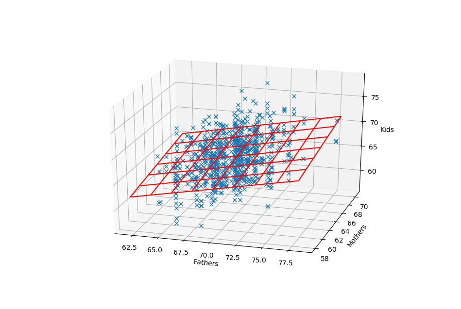

```python
fig = plt.figure()
ax = plt.axes(projection='3d')

# nuage de points père et mère
ax.plot3D(df['Father'],df['Mother'],df['Height'], 'x')

# réalisation du plan de régression
X = np.arange(df['Father'].min(), df['Father'].max(), 1)
Y = np.arange(df['Mother'].min(), df['Mother'].max(), 1)
X, Y = np.meshgrid(X, Y)
Z = theta1_father_mother0 * X + theta1_father_mother1 * Y + theta0_father_mother
ax.plot_wireframe(X,Y,Z,rstride=2, cstride=2, color='r')
ax.set_xlabel('Fathers')
ax.set_ylabel('Mothers')
ax.set_zlabel('Kids')
plt.show()
```

Le plan de régression, en rouge ci-dessus, nous permet de dire que plus le père et/ou la mère seront grands, plus leur enfant aura des chances d'être grand.

- Visualisons maintenant les résidus associés à ce modèle

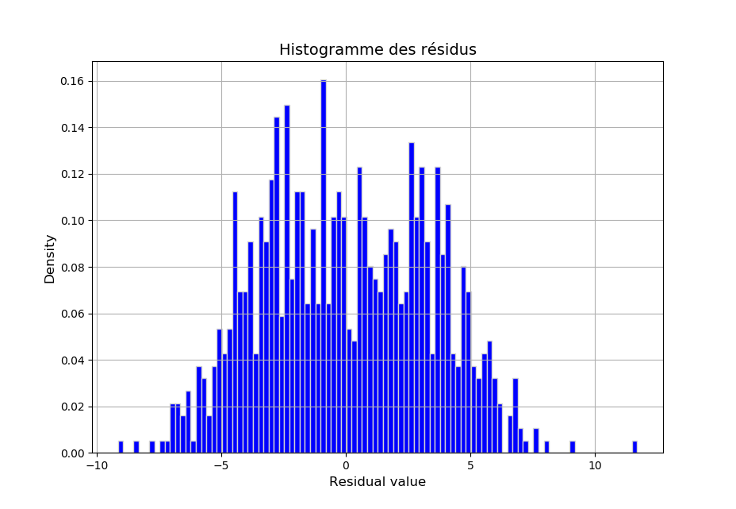

```python
residual_H_F = y - y_estim_father_mother

plt.figure()
plt.title('Histogramme des résidus', fontsize=14)
plt.xlabel('Residual value', fontsize=12)
plt.ylabel('Density', fontsize=12)
plt.hist(residual_H_F, density=True, bins=100, color='blue', edgecolor = 'lightgrey')
plt.grid(True)
plt.show()
```

## Question 13 :

A l’aide d’un échantillon test que nous allons construire comme précédemment, comparons la performance du modèle précédent à celle du modèle contenant seulement la variable *MeanParents*. Nous calculerons pour cela les risques de prédiction associés.

```python
# Création des échantillons de test et d'entraînement
df_train, df_test = train_test_split(df, test_size=0.2)

x_test = df_test[['MeanParents']]
y_test = df_test['Height']

X_test = df_test[['Father','Mother']]


x_train = df_train[['MeanParents']]
y_train = df_train['Height']

X_train = df_train[['Father','Mother']]
```

```python
# Entraînement des deux modèles et prédicteurs associés
# 1. MeanParents (question 4)
skl_lm.fit(x_train, y_train)
y_estim_1 = skl_lm.predict(x_test)

# 2. Father_Mother (question 12)
skl_lm_father_mother.fit(X_train, y_train)
y_estim_2 = skl_lm_father_mother.predict(X_test)
```

```python
# Calcul des risques de prédiction
r_predict_1 = (1/y_test.shape[0]) * sum((y_test - y_estim_1)**2)
print("Le risque de prédiction sur le modèle MeanParents vaut {}".format(r_predict_1))


r_predict_2 = (1/y_test.shape[0]) * sum((y_test - y_estim_2)**2)
print("Le risque de prédiction sur le modèle Father_Mother vaut {}".format(r_predict_2))
```

```
Le risque de prédiction sur le modèle MeanParents vaut 11.939932111199617
Le risque de prédiction sur le modèle Father_Mother vaut 12.09238851131722
```

**Commentaire :** Les risques de prédictions associés aux deux modèles sont très semblables. L'explication vient du fait que le facteur discriminant vient du sexe de l'enfant. Séparer les variables père et mère ne permettra pas d'obtenir une meilleure prédiction de la taille de l'enfant.